# SAÉ401 : Expliquer ou prédire une variable quantitative à l'aide de plusieurs facteurs

## Projet : Analyse consommation énergétique

Dans ce projet, nous avons étudié la consommation énergétique des logements à partir de deux sources de données :

La première est issue des DPE (Diagnostics de Performance Énergétique), qui donnent une estimation théorique de la consommation d’énergie d’un logement, calculée selon des normes.

La seconde provient d’Enedis, et contient les consommations réelles d’énergie mesurées à chaque adresse.

L’objectif principal est de comprendre quelles variables influencent le plus la consommation énergétique, et de construire des modèles de régression linéaire pour la prédire. Et suite voir si ces variables prédient plus la consommation obtenu par la DPE ou par celle obtenu par Enedis.

### Nettoyage des données

Pour réaliser l'ACP nous avons besoin de filtrer les données pour garder que des données numériques.

```python
import pandas as pd
import seaborn as sns
import matplotlib.pyplot as plt
import numpy as np
import string
from matplotlib.colors import LinearSegmentedColormap

# Charger les données
file_path = r"C:\Users\maria\Downloads\DATA (2).csv"
df = pd.read_csv(file_path)

# Nettoyage des colonnes
df_numeric = df.select_dtypes(include=['number'])

if "Version_DPE" in df_numeric.columns:
    df_numeric = df_numeric.drop(columns=["Version_DPE"])
colonnes_a_supprimer = [
    "Apports_internes_saison_froid",
    "Apports_solaires_saison_froid",
    "Besoin_refroidissement_dépensier",
    "Code_postal_(brut)",
    "Conso_refroidissement_dépensier_é_finale",
    "Conso_refroidissement_dépensier_é_primaire",
    "Conso_refroidissement_é_finale",
    "Conso_refroidissement_é_primaire",
    "Coût_refroidissement",
    "Coût_refroidissement_dépensier",
    "Emission_GES_refroidissement",
    "Emission_GES_refroidissement_dépensier",
    "Production_électricité_PV_(kWhep/an)"
]

df_numeric = df_numeric.drop(columns=[col for col in colonnes_a_supprimer if col in df_numeric.columns])


binary_cols = [col for col in df_numeric.columns if df_numeric[col].dropna().isin([0, 1]).all()]
df_numeric = df_numeric.drop(columns=binary_cols)

annee_cols = [col for col in df_numeric.columns if "année" in col.lower()]
df_numeric = df_numeric.drop(columns=annee_cols)

df_numeric = df_numeric.dropna(axis=1)
df_numeric = df_numeric.dropna()
```

### importer les données d'énedis

Vous pouvez trouvez les données par le lien suivant : [Données d'Enedis](https://data.enedis.fr/explore/dataset/consommation-annuelle-residentielle-par-adresse/export/)

```python
file_path = r"C:\Users\maria\Downloads\consommation-annuelle-residentielle-par-adresse.csv"
df_enedis = pd.read_csv(file_path, sep=';', engine='python', encoding='utf-8', on_bad_lines='skip')

# Vérifier les colonnes disponibles
print(df_enedis.columns)
```

```
Index(['Année', 'Code IRIS', 'Nom IRIS', 'Numéro de voie',
       'Indice de répétition', 'Type de voie', 'Libellé de voie',
       'Code Commune', 'Nom Commune', 'Segment de client',
       'Nombre de logements',
       'Consommation annuelle totale de l'adresse (MWh)',
       'Consommation annuelle moyenne par logement de l'adresse (MWh)',
       'Consommation annuelle moyenne de la commune (MWh)', 'Adresse',
       'Code EPCI', 'Code Département', 'Code Région', 'Tri des adresses'],
      dtype='object')
```

### Fusionner les données de enedis et les données de la DPE pour la modélisation la consommation reelle

```python
# Agrégation par Code Commune (moyenne ou somme selon logique métier)
df_enedis_agg = df_enedis.groupby("Code Commune")[["Consommation annuelle totale de l'adresse (MWh)"]].mean().reset_index()

# Renommer la colonne pour pouvoir faire le merge
df_enedis_agg = df_enedis_agg.rename(columns={"Code Commune": "Code_INSEE_(BAN)"})

df_fusion = pd.merge(df, df_enedis_agg, on="Code_INSEE_(BAN)", how="inner")
```

## Analyse en composantes principales (ACP)

Avant de construire un modèle de prédiction, il est important de bien comprendre les relations entre les variables. Pour cela, nous avons utilisé la matrice de corrélation, qui permet de visualiser les liens linéaires entre les différentes variables numériques.

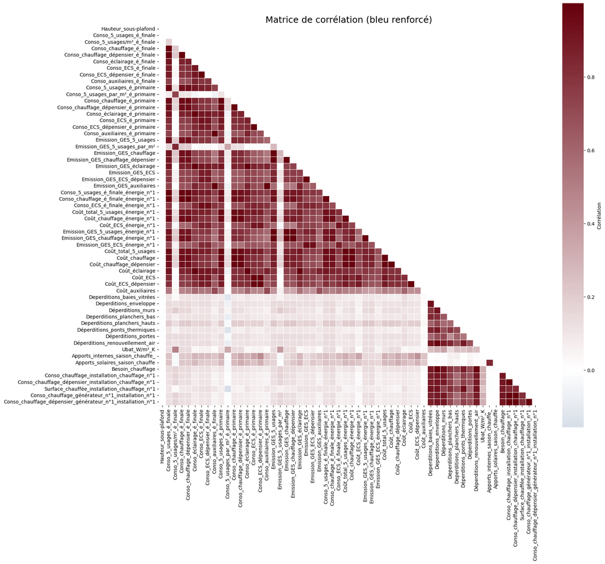

```python
# Standardisation
df_standardized = (df_numeric - df_numeric.mean()) / df_numeric.std()

# Corrélation + masque
corr_matrix = df_standardized.corr()
mask = np.triu(np.ones_like(corr_matrix, dtype=bool))

# Palette custom : bleu intense → blanc → rouge intense
colors = ["#08306B", "#ffffff", "#67000D"]
custom_cmap = LinearSegmentedColormap.from_list("stronger_blue_red", colors, N=256)

# Tracer la heatmap
plt.figure(figsize=(18, 16))
sns.heatmap(
    corr_matrix,
    mask=mask,
    cmap=custom_cmap,
    center=0,
    annot=False,
    square=True,
    linewidths=0.5,
    cbar_kws={"label": "Corrélation"}
)

plt.title("Matrice de corrélation (bleu renforcé)", fontsize=18)
plt.xticks(rotation=90, fontsize=10)
plt.yticks(rotation=0, fontsize=10)
plt.tight_layout()
plt.show()
```

La matrice de corrélation présentée ci-dessus nous permet de visualiser les relations linéaires entre toutes les variables numériques du jeu de données:

- Les valeurs proches de 1 (en rouge foncé) indiquent une forte corrélation positive : les deux variables augmentent ensemble.
- Les valeurs proches de 0 (blanc ou rose clair) indiquent peu ou pas de corrélation.
- Les valeurs proches de -1 (pas observées ici) indiqueraient une forte corrélation négative : quand une variable augmente, l'autre diminue.

Certaines variables sont très fortement corrélées entre elles, notamment :

- Conso_chauffage_é_finale et Conso_chauffage_dépensier_é_finale
- Conso_ECS_é_finale et Conso_ECS_dépensier_é_finale
- Conso_5_usages_é_finale et Conso_5_usages_é_primaire

Cela s’explique par le fait que ces variables décrivent des formes similaires de consommation (finale vs dépensier, ou finale vs primaire).

La consommation totale (Conso_5_usages_é_finale) est fortement corrélée à la plupart de ses composants (chauffage, ECS, éclairage…).

```python
print(corr_matrix.head())
```

```
                                    Hauteur_sous-plafond  \
Hauteur_sous-plafond                            1.000000
Conso_5_usages_é_finale                         0.000811
Conso_5_usages/m²_é_finale                      0.008920
Conso_chauffage_é_finale                        0.001764
Conso_chauffage_dépensier_é_finale              0.001672

                                    Conso_5_usages_é_finale  \
Hauteur_sous-plafond                               0.000811
Conso_5_usages_é_finale                            1.000000
Conso_5_usages/m²_é_finale                         0.174990
Conso_chauffage_é_finale                           0.987331
Conso_chauffage_dépensier_é_finale                 0.988792

                                    Conso_5_usages/m²_é_finale  \
Hauteur_sous-plafond                                  0.008920
Conso_5_usages_é_finale                               0.174990
Conso_5_usages/m²_é_finale                            1.000000
Conso_chauffage_é_finale                              0.216934
Conso_chauffage_dépensier_é_finale                    0.209898

                                    Conso_chauffage_é_finale  \
Hauteur_sous-plafond                                0.001764
Conso_5_usages_é_finale                             0.987331
Conso_5_usages/m²_é_finale                          0.216934
Conso_chauffage_é_finale                            1.000000
Conso_chauffage_dépensier_é_finale                  0.999742

                                    Conso_chauffage_dépensier_é_finale  \
Hauteur_sous-plafond                                          0.001672
Conso_5_usages_é_finale                                       0.988792
Conso_5_usages/m²_é_finale                                    0.209898
Conso_chauffage_é_finale                                      0.999742
Conso_chauffage_dépensier_é_finale                            1.000000

                                    Conso_éclairage_é_finale  \
Hauteur_sous-plafond                               -0.001578
Conso_5_usages_é_finale                             0.912602
Conso_5_usages/m²_é_finale                         -0.006406
Conso_chauffage_é_finale                            0.859810
```

[output cut: 86 more lines]

```
                                    Conso_chauffage_générateur_n°1_installation_n°1  \
Hauteur_sous-plafond                                                      -0.003458
Conso_5_usages_é_finale                                                    0.123834
Conso_5_usages/m²_é_finale                                                 0.172281
Conso_chauffage_é_finale                                                   0.126905
Conso_chauffage_dépensier_é_finale                                         0.127911

                                    Conso_chauffage_dépensier_générateur_n°1_installation_n°1
Hauteur_sous-plafond                                                        -0.003567
Conso_5_usages_é_finale                                                      0.123195
Conso_5_usages/m²_é_finale                                                   0.168078
Conso_chauffage_é_finale                                                     0.125994
Conso_chauffage_dépensier_é_finale                                           0.127076

[5 rows x 58 columns]
```

### Calcul des valeurs propres

```python
# Étape 4 : Calcul des valeurs propres et vecteurs propres
A = corr_matrix.to_numpy()
valeurs_propres, vecteurs_propres = np.linalg.eig(A)

# Étape 5 : Trier les valeurs propres décroissantes
indices_tries = np.argsort(valeurs_propres)[::-1]
valeurs_propres_tries = valeurs_propres[indices_tries]
vecteurs_propres_tries = vecteurs_propres[:, indices_tries]
somme_valeurs_propres = np.sum(valeurs_propres_tries)
# Affichage des résultats
print("Valeurs propres :")
print(valeurs_propres_tries)

print("\nVecteurs propres (colonnes) :")
print(vecteurs_propres_tries)


print("Somme des valeurs propres :", somme_valeurs_propres)
```

```
Valeurs propres :
[3.02138837e+01 1.14033161e+01 3.50666146e+00 2.02250814e+00
 1.86490895e+00 1.54134919e+00 1.30828464e+00 1.00003157e+00
 8.31455751e-01 7.13114324e-01 6.07658182e-01 5.43728793e-01
 4.75898896e-01 3.34302728e-01 2.83901746e-01 2.31005801e-01
 2.14522236e-01 2.02928650e-01 1.55020758e-01 1.16641431e-01
 1.02118837e-01 9.19458644e-02 4.99820460e-02 3.85138644e-02
 3.40609420e-02 2.76828356e-02 1.85568851e-02 1.54561899e-02
 1.21085025e-02 1.02777605e-02 8.14458243e-03 3.74621573e-03
 2.90801407e-03 2.66531812e-03 2.23417391e-03 1.79544971e-03
 1.56939066e-03 1.33528406e-03 1.22381377e-03 7.16582717e-04
 4.67128534e-04 3.21672459e-04 2.82712775e-04 2.12861664e-04
 1.48195126e-04 1.12318754e-04 1.04114345e-04 8.71536553e-05
 4.47220563e-05 2.95724755e-05 1.19917155e-05 6.82093289e-06
 2.06059387e-06 1.86824784e-06 9.83421856e-07 2.55056884e-07
 2.06410518e-09 5.84076696e-13]

Vecteurs propres (colonnes) :
[[-1.06746164e-04  1.75977730e-03 -8.59332489e-03 ... -9.83177457e-07
  -3.88263907e-07 -5.19290159e-09]
 [ 1.77554791e-01  1.58978495e-02 -6.63008754e-02 ...  2.30122547e-03
  -3.29490308e-04  6.91875607e-01]
 [ 2.40652176e-02 -4.55651396e-02 -3.93309722e-01 ...  3.23480845e-05
   9.88860810e-08 -2.31764046e-08]
 ...
 [ 3.05242309e-02 -2.68207812e-01  8.73964591e-02 ... -2.60582473e-04
  -1.08627531e-05 -1.65017811e-07]
 [ 3.17307969e-02 -2.76004101e-01 -5.06992705e-03 ... -4.97438899e-01
   4.69609248e-03 -4.83487036e-05]
 [ 3.16773637e-02 -2.76427999e-01 -2.84043458e-03 ...  4.92708489e-01
  -4.68220750e-03  4.79906972e-05]]
Somme des valeurs propres : 58.00000000000007
```

### Calcul de l'inertie cumulée

```python
# Calcul de la somme des valeurs propres
somme_valeurs_propres = sum(valeurs_propres)

# Calcul des pourcentages d'inertie
pourcentages_inertie = [(valeur / somme_valeurs_propres) * 100 for valeur in valeurs_propres_tries]

# Calcul des pourcentages cumulés
pourcentages_inertie_cumules = [sum(pourcentages_inertie[:i+1]) for i in range(len(pourcentages_inertie))]

# Affichage des résultats
print("Pourcentages d'inertie par axe :")
for i, pourcentage in enumerate(pourcentages_inertie):
    print(f"Axe {i+1}: {pourcentage:.2f}%")

print("\nPourcentages d'inertie cumulés :")
for i, pourcentage in enumerate(pourcentages_inertie_cumules):
    print(f"Axe {i+1}: {pourcentage:.2f}%")
```

```
Pourcentages d'inertie par axe :
Axe 1: 52.09%
Axe 2: 19.66%
Axe 3: 6.05%
Axe 4: 3.49%
Axe 5: 3.22%
Axe 6: 2.66%
Axe 7: 2.26%
Axe 8: 1.72%
Axe 9: 1.43%
Axe 10: 1.23%
Axe 11: 1.05%
Axe 12: 0.94%
Axe 13: 0.82%
Axe 14: 0.58%
Axe 15: 0.49%
Axe 16: 0.40%
Axe 17: 0.37%
Axe 18: 0.35%
Axe 19: 0.27%
Axe 20: 0.20%
Axe 21: 0.18%
Axe 22: 0.16%
Axe 23: 0.09%
Axe 24: 0.07%
Axe 25: 0.06%
Axe 26: 0.05%
Axe 27: 0.03%
Axe 28: 0.03%
Axe 29: 0.02%
Axe 30: 0.02%
Axe 31: 0.01%
Axe 32: 0.01%
Axe 33: 0.01%
Axe 34: 0.00%
Axe 35: 0.00%
Axe 36: 0.00%
Axe 37: 0.00%
Axe 38: 0.00%
Axe 39: 0.00%
```

[output cut: 64 more lines]

```
Axe 44: 100.00%
Axe 45: 100.00%
Axe 46: 100.00%
Axe 47: 100.00%
Axe 48: 100.00%
Axe 49: 100.00%
Axe 50: 100.00%
Axe 51: 100.00%
Axe 52: 100.00%
Axe 53: 100.00%
Axe 54: 100.00%
Axe 55: 100.00%
Axe 56: 100.00%
Axe 57: 100.00%
Axe 58: 100.00%
```

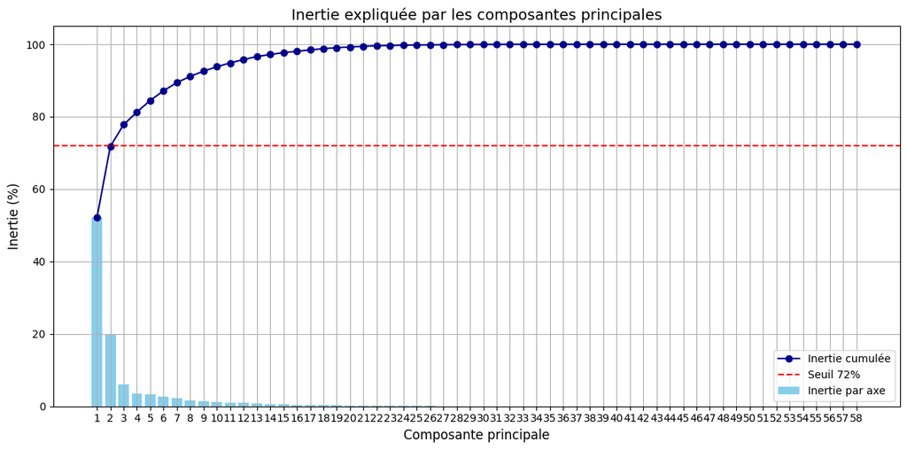

```python
# Reprendre les pourcentages d'inertie (déjà triés)
axes = np.arange(1, len(pourcentages_inertie) + 1)

plt.figure(figsize=(12, 6))

# Barplot pour les inerties individuelles
plt.bar(axes, pourcentages_inertie, color='skyblue', label="Inertie par axe")

# Ligne pour l'inertie cumulée
plt.plot(axes, pourcentages_inertie_cumules, color='darkblue', marker='o', label="Inertie cumulée")

# Ligne horizontale de référence à 80%
plt.axhline(y=72, color='red', linestyle='--', label="Seuil 72%")

plt.title("Inertie expliquée par les composantes principales", fontsize=14)
plt.xlabel("Composante principale", fontsize=12)
plt.ylabel("Inertie (%)", fontsize=12)
plt.xticks(axes)
plt.legend()
plt.grid(True)
plt.tight_layout()
plt.show()
```

Le graphe ci-dessus représente l’inertie expliquée par chaque composante principale de l’ACP, ainsi que l’inertie cumulée.

- On observe que les deux premières composantes principales expliquent déjà environ 72 % de la variance totale des données.
- Cela signifie qu’en ne gardant que ces deux axes, on conserve l’essentiel de l’information, tout en réduisant fortement la dimension du jeu de données.

```python
# Calcul de la norme au carré des deux premiers vecteurs propres
norme_carre_vecteur_1 = np.sum(vecteurs_propres[:, 0]**2)
norme_carre_vecteur_2 = np.sum(vecteurs_propres[:, 1]**2)
# Calcul du produit scalaire entre les deux premiers vecteurs propres
produit_scalaire = np.dot(vecteurs_propres[:, 0], vecteurs_propres[:, 1])

print("Produit scalaire entre les deux premiers vecteurs propres : ", produit_scalaire)


print("Norme au carré du premier vecteur propre : ", norme_carre_vecteur_1)
print("Norme au carré du deuxième vecteur propre : ", norme_carre_vecteur_2)
```

```
Produit scalaire entre les deux premiers vecteurs propres :  4.597017211338539e-16
Norme au carré du premier vecteur propre :  0.9999999999999999
Norme au carré du deuxième vecteur propre :  1.0
```

La norme au carré des deux premiers vecteurs propres est très proche de 1, ce qui signifie qu’ils sont normés. Leur produit scalaire est quasiment nul, ce qui montre qu’ils sont orthogonaux, donc indépendants.

On peut donc dire qu’ils forment une base orthonormée, et on pourra représenter les données suivant ces deux axes.

```python
# Matrice de passage : les 2 premiers vecteurs propres (axes F1 et F2)
Pass = vecteurs_propres_tries[:, :2]

# Projection des individus : X_standardisé · Pass
compos_princ = df_standardized.to_numpy() @ Pass

# Convertir en DataFrame avec noms des axes
df_compos_princ = pd.DataFrame(compos_princ, columns=["F1", "F2"])

# Afficher un aperçu
print(df_compos_princ.head())
```

```
         F1        F2
0  0.290244  1.185948
1 -1.198901  1.340100
2 -0.392755  0.380444
3 -1.436254  1.093821
4 -0.745425  1.284653
```

### Représentation des individus dans la base factorielle

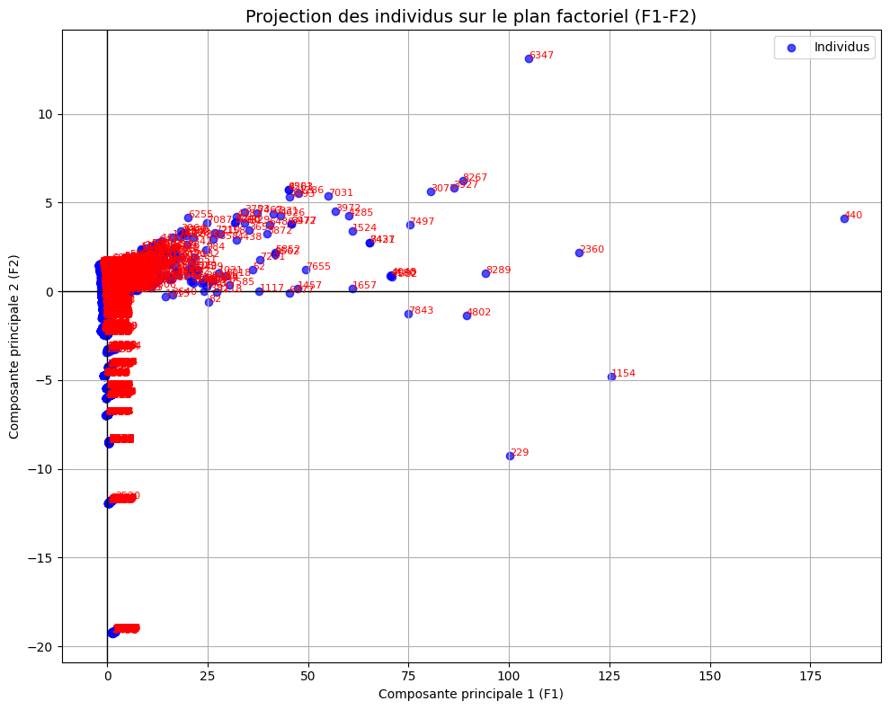

```python
# Vérifie que les colonnes F1 et F2 existent bien
if "F1" in df_compos_princ.columns and "F2" in df_compos_princ.columns:
    plt.figure(figsize=(10, 8))

    # Nuage des individus
    plt.scatter(df_compos_princ["F1"], df_compos_princ["F2"], color='blue', alpha=0.7, label="Individus")

    # Ajout des labels (indices)
    for i, (x, y) in enumerate(zip(df_compos_princ["F1"], df_compos_princ["F2"])):
        plt.text(x, y, str(i), color='red', fontsize=8)

    # Axes centraux
    plt.axhline(0, color='black', linewidth=1)
    plt.axvline(0, color='black', linewidth=1)

    # Titres et légendes
    plt.title("Projection des individus sur le plan factoriel (F1-F2)", fontsize=14)
    plt.xlabel("Composante principale 1 (F1)")
    plt.ylabel("Composante principale 2 (F2)")
    plt.grid(True)
    plt.tight_layout()
    plt.legend()
    plt.show()
else:
    print("Les colonnes 'F1' et 'F2' sont manquantes dans df_compos_princ.")
```

Ce graphique représente chaque individu projeté dans le plan défini par les deux premières composantes principales issues de l’ACP.

```python
# Exemple : df_compos_princ contient déjà F1 et F2
# Et valeurs_propres contient les valeurs propres associées aux composantes

# --- Étape 1 : Calcul de la qualité de représentation (cos²) ---
# cos² = coordonnée² / distance au centre de gravité
squared_dist = df_compos_princ["F1"]**2 + df_compos_princ["F2"]**2
df_qualite = pd.DataFrame({
    "cos² F1": df_compos_princ["F1"]**2 / squared_dist,
    "cos² F2": df_compos_princ["F2"]**2 / squared_dist
})

# --- Étape 2 : Calcul de la contribution des individus (CTR) ---
n = df_compos_princ.shape[0]  # nombre d'individus
ctr_F1 = df_compos_princ["F1"]**2 * 100 / (n * valeurs_propres[0])
ctr_F2 = df_compos_princ["F2"]**2 * 100 / (n * valeurs_propres[1])
df_contrib = pd.DataFrame({
    "CTR F1 (%)": ctr_F1,
    "CTR F2 (%)": ctr_F2
})

# --- Étape 3 : Fusion des résultats ---
df_individus = pd.concat([df_compos_princ, df_qualite, df_contrib], axis=1)

# --- Étape 4 : Top 10 contributeurs par axe ---
top10_F1 = df_individus.sort_values(by="CTR F1 (%)", ascending=False).head(10)
top10_F2 = df_individus.sort_values(by="CTR F2 (%)", ascending=False).head(10)

# Affichage des résultats
print("Top 10 contributeurs à F1 :")
print(top10_F1)

print("\nTop 10 contributeurs à F2 :")
print(top10_F2)
```

```
Top 10 contributeurs à F1 :
              F1         F2   cos² F1   cos² F2  CTR F1 (%)  CTR F2 (%)
440   183.352109   4.084435  0.999504  0.000496   12.762872    0.016781
1154  125.389707  -4.787355  0.998544  0.001456    5.968983    0.023054
2360  117.473293   2.179276  0.999656  0.000344    5.239078    0.004777
6347  104.968458  13.100589  0.984663  0.015337    4.183061    0.172637
229   100.236588  -9.258673  0.991540  0.008460    3.814425    0.086228
8289   94.266026   1.006393  0.999886  0.000114    3.373549    0.001019
4802   89.412854  -1.356275  0.999770  0.000230    3.035124    0.001850
8267   88.479290   6.242848  0.995046  0.004954    2.972076    0.039203
3927   86.249122   5.851554  0.995418  0.004582    2.824138    0.034442
3077   80.620605   5.647289  0.995117  0.004883    2.467565    0.032080

Top 10 contributeurs à F2 :
            F1         F2   cos² F1   cos² F2  CTR F1 (%)  CTR F2 (%)
3451  1.303205 -19.269175  0.004553  0.995447    0.000645    0.373489
2895  1.187449 -19.243260  0.003793  0.996207    0.000535    0.372485
2393  1.187449 -19.243260  0.003793  0.996207    0.000535    0.372485
3303  1.187449 -19.243260  0.003793  0.996207    0.000535    0.372485
3232  1.187449 -19.243260  0.003793  0.996207    0.000535    0.372485
3449  1.187449 -19.243260  0.003793  0.996207    0.000535    0.372485
1549  1.187449 -19.243260  0.003793  0.996207    0.000535    0.372485
1061  1.187449 -19.243260  0.003793  0.996207    0.000535    0.372485
3334  1.654823 -19.234020  0.007348  0.992652    0.001040    0.372128
3321  1.606270 -19.227054  0.006931  0.993069    0.000980    0.371858
```

Dans le cadre de l’ACP, on cherche à savoir quels individus contribuent le plus à la construction des axes principaux (F1 et F2). Plus un individu contribue, plus il a une influence sur l’orientation de l’axe.

Lecture des colonnes :

- F1 / F2 : Coordonnées de l’individu sur l’axe F1 ou F2.
- cos² F1 / cos² F2 : Qualité de représentation sur l’axe (plus c’est proche de 1, mieux c’est).
- CTR F1 (%) / CTR F2 (%) : Contribution en pourcentage de l’individu à la construction de l’axe.

Axe F1 :

- Les individus n°440, 1154, 2360, 6347 sont ceux qui contribuent le plus à F1. Par exemple, l’individu 440 explique à lui seul 12.76% de l’axe F1, ce qui est énorme !
- Leurs cos² sont très proches de 1, ce qui signifie qu’ils sont très bien représentés dans le plan.
- Ces individus sont donc très caractéristiques et influents pour comprendre la première dimension de la variabilité des données.

Axe F2 :

- L’axe F2 est principalement influencé par d’autres individus très spécifiques : 3451, 2895, 2393, etc.
- Contrairement à F1, les contributions sont plus équilibrées ici (autour de 0.37% chacun).
- Cela montre que F2 est moins dominé par quelques individus, et se construit de façon plus homogène.

### Cercle de correlation

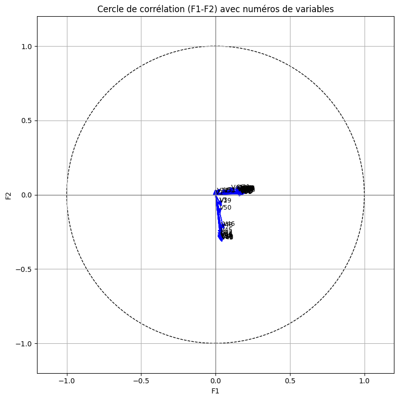

```
                                    Nom de la variable
V1                                Hauteur_sous-plafond
V2                             Conso_5_usages_é_finale
V3                          Conso_5_usages/m²_é_finale
V4                            Conso_chauffage_é_finale
V5                  Conso_chauffage_dépensier_é_finale
V6                            Conso_éclairage_é_finale
V7                                  Conso_ECS_é_finale
V8                        Conso_ECS_dépensier_é_finale
V9                          Conso_auxiliaires_é_finale
V10                          Conso_5_usages_é_primaire
V11                   Conso_5_usages_par_m²_é_primaire
V12                         Conso_chauffage_é_primaire
V13               Conso_chauffage_dépensier_é_primaire
V14                         Conso_éclairage_é_primaire
V15                               Conso_ECS_é_primaire
V16                     Conso_ECS_dépensier_é_primaire
V17                       Conso_auxiliaires_é_primaire
V18                              Emission_GES_5_usages
V19                       Emission_GES_5_usages_par_m²
V20                             Emission_GES_chauffage
V21                   Emission_GES_chauffage_dépensier
V22                             Emission_GES_éclairage
V23                                   Emission_GES_ECS
V24                         Emission_GES_ECS_dépensier
V25                           Emission_GES_auxiliaires
V26                Conso_5_usages_é_finale_énergie_n°1
V27               Conso_chauffage_é_finale_énergie_n°1
V28                     Conso_ECS_é_finale_énergie_n°1
V29                    Coût_total_5_usages_énergie_n°1
V30                         Coût_chauffage_énergie_n°1
V31                               Coût_ECS_énergie_n°1
V32                  Emission_GES_5_usages_énergie_n°1
V33                 Emission_GES_chauffage_énergie_n°1
V34                       Emission_GES_ECS_énergie_n°1
V35                                Coût_total_5_usages
V36                                     Coût_chauffage
V37                           Coût_chauffage_dépensier
V38                                     Coût_éclairage
V39                                           Coût_ECS
V40                                 Coût_ECS_dépensier
V41                                   Coût_auxiliaires
V42                         Deperditions_baies_vitrées
V43                             Deperditions_enveloppe
V44                                  Déperditions_murs
V45                         Deperditions_planchers_bas
V46                       Deperditions_planchers_hauts
V47                      Déperditions_ponts_thermiques
V48                                Déperditions_portes
V49                    Déperditions_renouvellement_air
V50                                        Ubat_W/m²_K
V51                   Apports_internes_saison_chauffe_
V52                    Apports_solaires_saison_chauffe
V53                                   Besoin_chauffage
V54         Conso_chauffage_installation_chauffage_n°1
V55  Conso_chauffage_dépensier_installation_chauffa...
V56        Surface_chauffée_installation_chauffage_n°1
V57    Conso_chauffage_générateur_n°1_installation_n°1
V58  Conso_chauffage_dépensier_générateur_n°1_insta...
```

```python
# --- Données nécessaires ---
# V : matrice des vecteurs propres (shape = [nb_variables, nb_composantes])
# df_standardized : DataFrame contenant les variables initiales standardisées

# Coordonnées sur F1 et F2
coord_f1_f2 = vecteurs_propres[:, :2]  # coordonnées des variables sur les axes F1 et F2
noms_variables = df_standardized.columns

# Générer des numéros pour les labels
numero_labels = [f"V{i+1}" for i in range(len(noms_variables))]

# Dictionnaire de correspondance si tu veux afficher ensuite le tableau
dico_num_var = dict(zip(numero_labels, noms_variables))

# --- Tracer le cercle de corrélation ---
plt.figure(figsize=(8, 8))
plt.axhline(0, color='grey', linewidth=1)
plt.axvline(0, color='grey', linewidth=1)

# Cercle unité
circle = plt.Circle((0, 0), 1, color='black', fill=False, linestyle='--')
plt.gca().add_artist(circle)

# Flèches et numéros
for i in range(coord_f1_f2.shape[0]):
    x, y = coord_f1_f2[i]
    plt.arrow(0, 0, x, y, head_width=0.03, head_length=0.03, fc='blue', ec='blue')
    plt.text(x * 1.05, y * 1.05, numero_labels[i], color='black', fontsize=9)

# Mise en forme
plt.xlabel("F1")
plt.ylabel("F2")
plt.title("Cercle de corrélation (F1-F2) avec numéros de variables")
plt.xlim(-1.2, 1.2)
plt.ylim(-1.2, 1.2)
plt.grid(True)
plt.gca().set_aspect('equal', adjustable='box')
plt.tight_layout()
plt.show()

# --- Affichage du dictionnaire des correspondances (facultatif) ---
df_correspondance = pd.DataFrame.from_dict(dico_num_var, orient='index', columns=["Nom de la variable"])
print(df_correspondance)
```

Le cercle de corrélation permet de visualiser comment les variables initiales sont représentées sur les deux premières composantes principales (F1 et F2) issues de l'ACP. Dans ce graphique, on remarque que la majorité des flèches sont orientées dans la direction de l’axe F1, avec des longueurs relativement courtes, ce qui indique que ces variables sont globalement bien corrélées à la première composante mais mal représentées. Les flèches les plus longues montrent les variables qui sont les mieux représentées par le plan factoriel F1-F2. Cela signifie qu'elles contribuent fortement à la formation des axes et qu’elles portent une information importante dans l’analyse. À l’inverse, les flèches très courtes et proches du centre sont des variables mal projetées, qui s’expriment probablement sur d’autres axes. Enfin, l’orientation des flèches nous renseigne sur les relations entre variables : des flèches proches et alignées indiquent des corrélations positives, tandis que des flèches opposées suggèrent des corrélations négatives.

```python
# V contient les coordonnées des variables sur les composantes (vecteurs propres)
# eigenvalues contient les valeurs propres associées aux composantes principales
# df_standardized.columns contient les noms des variables standardisées

eigenvalues = np.linalg.eigvals(corr_matrix)

# === Étape 1 : Qualité de représentation (cos²) ===
# cos² = coordonnée² (car les vecteurs sont normés)
cos2_vars = vecteurs_propres[:, :2]**2  # uniquement F1 et F2
df_cos2_vars = pd.DataFrame(
    cos2_vars,
    columns=["cos² F1", "cos² F2"],
    index=df_standardized.columns
)

# === Étape 2 : Contribution des variables à chaque axe ===
# Formule : (coordonnée² / valeur propre) * 100
ctr_vars = (vecteurs_propres[:, :2]**2) * 100 / eigenvalues[:2]
df_ctr_vars = pd.DataFrame(
    ctr_vars,
    columns=["CTR F1 (%)", "CTR F2 (%)"],
    index=df_standardized.columns
)

# === Étape 3 : Fusion des résultats ===
df_variables = pd.concat([df_cos2_vars, df_ctr_vars], axis=1)

# === Étape 4 : Affichage des top contributeurs ===
top10_vars_F1 = df_variables.sort_values(by="CTR F1 (%)", ascending=False).head(10)
top10_vars_F2 = df_variables.sort_values(by="CTR F2 (%)", ascending=False).head(10)

# Affichage
print("Top 10 variables contributrices à F1 :")
print(top10_vars_F1)

print("\nTop 10 variables contributrices à F2 :")
print(top10_vars_F2)
```

```
Top 10 variables contributrices à F1 :
                                       cos² F1   cos² F2  CTR F1 (%)  \
Conso_5_usages_é_finale_énergie_n°1   0.031614  0.000285    0.104634
Conso_5_usages_é_finale               0.031526  0.000253    0.104342
Coût_total_5_usages                   0.031344  0.000723    0.103741
Conso_5_usages_é_primaire             0.030641  0.000686    0.101413
Coût_total_5_usages_énergie_n°1       0.030245  0.000907    0.100103
Coût_chauffage_énergie_n°1            0.029549  0.000555    0.097799
Conso_chauffage_dépensier_é_finale    0.029352  0.000157    0.097148
Conso_chauffage_é_finale_énergie_n°1  0.029226  0.000124    0.096730
Conso_chauffage_é_finale              0.029162  0.000159    0.096519
Coût_chauffage                        0.029144  0.000603    0.096459

                                      CTR F2 (%)
Conso_5_usages_é_finale_énergie_n°1     0.002502
Conso_5_usages_é_finale                 0.002216
Coût_total_5_usages                     0.006343
Conso_5_usages_é_primaire               0.006019
Coût_total_5_usages_énergie_n°1         0.007952
Coût_chauffage_énergie_n°1              0.004865
Conso_chauffage_dépensier_é_finale      0.001373
Conso_chauffage_é_finale_énergie_n°1    0.001087
Conso_chauffage_é_finale                0.001392
Coût_chauffage                          0.005288

Top 10 variables contributrices à F2 :
                                                     cos² F1   cos² F2  \
Deperditions_enveloppe                              0.001502  0.081550
Besoin_chauffage                                    0.001400  0.080938
Déperditions_renouvellement_air                     0.001389  0.078966
Conso_chauffage_dépensier_installation_chauffag...  0.000998  0.077364
Conso_chauffage_installation_chauffage_n°1          0.001001  0.077164
Conso_chauffage_dépensier_générateur_n°1_instal...  0.001003  0.076412
Conso_chauffage_générateur_n°1_installation_n°1     0.001007  0.076178
Deperditions_baies_vitrées                          0.001099  0.072805
Surface_chauffée_installation_chauffage_n°1         0.000932  0.071935
Déperditions_murs                                   0.001333  0.069603

                                                    CTR F1 (%)  CTR F2 (%)
Deperditions_enveloppe                                0.004972    0.715143
Besoin_chauffage                                      0.004632    0.709779
Déperditions_renouvellement_air                       0.004596    0.692487
Conso_chauffage_dépensier_installation_chauffag...    0.003302    0.678437
Conso_chauffage_installation_chauffage_n°1            0.003314    0.676678
Conso_chauffage_dépensier_générateur_n°1_instal...    0.003321    0.670090
Conso_chauffage_générateur_n°1_installation_n°1       0.003332    0.668036
Deperditions_baies_vitrées                            0.003638    0.638451
Surface_chauffée_installation_chauffage_n°1           0.003084    0.630829
Déperditions_murs                                     0.004411    0.610375
```

Interprétation des contributions à F1 Les 10 variables qui contribuent le plus à F1 sont majoritairement liées à la consommation globale d’énergie et aux coûts associés.

Exemples de variables fortement contributrices :

- Conso_5_usages_é_finale
- Conso_5_usages_é_finale_énergie_n°1
- Coût_total_5_usages
- C- oût_chauffage

L’axe F1 synthétise principalement le niveau de consommation énergétique global des logements.

Interprétation des contributions à F2 Les 10 plus fortes contributions à F2 proviennent de variables liées à :

- L’enveloppe thermique du logement : Déperditions_enveloppe, Déperditions_murs, etc.
- Le besoin de chauffage : Besoin_chauffage, Surface_chauffée, etc.

F2 est plutôt un axe qui décrit la performance thermique du bâtiment, c’est-à-dire ses pertes d’énergie et son isolation.

Ces variables sont faiblement projetées sur F1 mais bien visibles sur F2 dans le cercle de corrélation.

## Modélisation linéaire de la consommation total de la DPE

### Variables trop corrélées avec la consommation des 5 usages finale

- Conso_chauffage_é_finale
- Conso_chauffage_dépensier_é_finale
- Conso_ECS_é_finale
- Conso_ECS_dépensier_é_finale
- Conso_5_usages_é_primaire

### variables retenues

```python
variables_finales = [
    'Conso_éclairage_é_finale', 'Conso_auxiliaires_é_finale',
    'Conso_chauffage_é_primaire', 'Conso_chauffage_dépensier_é_primaire',
    'Conso_éclairage_é_primaire', 'Emission_GES_5_usages',
    'Emission_GES_chauffage', 'Conso_chauffage_é_finale_énergie_n°1',
    'Conso_ECS_é_finale_énergie_n°1', 'Coût_chauffage_énergie_n°1',
    'Coût_ECS_énergie_n°1', 'Emission_GES_5_usages_énergie_n°1',
    'Emission_GES_ECS_énergie_n°1', 'Coût_total_5_usages',
    'Coût_chauffage', 'Coût_chauffage_dépensier', 'Coût_éclairage'
]
```

### fonction pour calculer m_chapeau

```python
def calculer_m_chapeau(X: np.ndarray, Y: np.ndarray) -> np.ndarray:
    """
    Calcule les coefficients m_chapeau d'une régression linéaire multiple.

    Paramètres :
    - X : matrice des variables explicatives (avec constante en 1ère colonne)
    - Y : vecteur colonne de la variable à prédire

    Retour :
    - m_chapeau : vecteur colonne des coefficients estimés
    """
    XtX = X.T @ X
    XtX_inv = np.linalg.inv(XtX)
    XtY = X.T @ Y
    m_chapeau = XtX_inv @ XtY
    return m_chapeau
```

### fonction pour calculer R²

```python
def calculer_r_carre(Y: np.ndarray, Y_hat: np.ndarray) -> float:
    """
    Calcule le coefficient de détermination R².

    Paramètres :
    - Y : valeurs observées
    - Y_hat : valeurs estimées

    Retour :
    - R²
    """
    SCE = np.sum((Y - Y_hat) ** 2)
    SCT = np.sum((Y - np.mean(Y)) ** 2)
    return 1 - (SCE / SCT)
```

```python
# --- Étape 2 : Matrices X et Y ---
X_vars = df_numeric[variables_finales].copy()
X = np.column_stack((np.ones(X_vars.shape[0]), X_vars.values))  # constante
X_T = X.T
Y = df_numeric["Conso_5_usages_é_finale"].values.reshape(-1, 1)


# Optionnel : afficher la forme
print("Dimensions de X :", X.shape)
print("Dimensions de X^T :", X_T.shape)


# --- Étape 3 : Calcul matriciel ---
XtX = X_T @ X
XtX_inv = np.linalg.inv(XtX)
XtY = X_T @ Y
m_chapeau = XtX_inv @ XtY

# --- Étape 4 : Génération de noms symboliques ---
def generate_chapeau_labels(n):
    base = list(string.ascii_lowercase)
    labels = []
    for i in range(n):
        if i < 26:
            labels.append(f"{base[i]}_chapeau")
        else:
            first = base[(i // 26) - 1]
            second = base[i % 26]
            labels.append(f"{first}{second}_chapeau")
    return labels

chapeau_labels = generate_chapeau_labels(m_chapeau.shape[0])  # ex: a_chapeau, b_chapeau...

# --- Étape 5 : Affichage du résultat ---
m_chapeau_df = pd.DataFrame(m_chapeau,
                             index=chapeau_labels,
                             columns=["m_chapeau (coefficient)"])
print(m_chapeau_df)
```

```
Dimensions de X : (8718, 18)
Dimensions de X^T : (18, 8718)
           m_chapeau (coefficient)
a_chapeau                10.358826
b_chapeau              -661.400578
c_chapeau                 0.069281
d_chapeau                 0.211069
e_chapeau                 0.063983
f_chapeau               285.732168
g_chapeau                 1.386092
h_chapeau                 0.555779
i_chapeau                 0.683107
j_chapeau                 1.227004
k_chapeau                -3.526495
l_chapeau                -3.239678
m_chapeau                -1.035302
n_chapeau                -1.400591
o_chapeau                 2.524526
p_chapeau                 0.789206
q_chapeau                -1.288992
r_chapeau                21.049481
```

```python
# --- Étape : Calcul des estimations ---
Y_hat= X @ m_chapeau  # produit matriciel

# --- Conversion en DataFrame pour affichage ---
Y_hat_df = pd.DataFrame(Y_hat, columns=["Consommation réelle estimée (MWh)"])

# Affichage des 10 premières estimations
print("🔮 Estimations (Y_hat_enedis) :")
print(Y_hat_df.head(10))

# --- Étape : Calcul des résidus ---
residus = Y - Y_hat

# --- Étape : Coefficient de détermination R² ---
R2 = calculer_r_carre(Y, Y_hat)

# --- Affichage ---
print("📉 Résidus (extraits) :")
print(residus[:10])

print(f"\n📊 R² (coefficient de détermination sur conso DPE) : {R2:.4f}")
```

[output not shown]

Le coefficient de détermination R² égal à 0.9985 indique que la régression linéaire explique quasiment toute la variabilité de la consommation énergétique estimée par le DPE. Cela signifie que les prédictions sont très proches des valeurs réelles, avec une marge d’erreur extrêmement faible.

## Modélisation de la consommation d'énergie à partir des données de ENEDIS

```python
# --- Étape 2 : Matrices X et Y (à partir de df_fusion) ---
X_vars = df_fusion[variables_finales].copy()
X = np.column_stack((np.ones(X_vars.shape[0]), X_vars.values))  # ajout constante
Y = df_fusion["Consommation annuelle totale de l'adresse (MWh)"].values.reshape(-1, 1)

# Vérification dimensions
print("Dimensions de X :", X.shape)
print("Dimensions de X^T :", X.T.shape)

# --- Étape 3 : Estimation des coefficients ---
m_chapeau = calculer_m_chapeau(X, Y)

# --- Étape 4 : Génération des noms symboliques ---
def generate_chapeau_labels(n):
    base = list(string.ascii_lowercase)
    labels = []
    for i in range(n):
        if i < 26:
            labels.append(f"{base[i]}_chapeau")
        else:
            first = base[(i // 26) - 1]
            second = base[i % 26]
            labels.append(f"{first}{second}_chapeau")
    return labels

chapeau_labels = generate_chapeau_labels(m_chapeau.shape[0])

# --- Étape 5 : Affichage des coefficients ---
m_chapeau_df = pd.DataFrame(m_chapeau,
                             index=chapeau_labels,
                             columns=["m_chapeau (coefficient)"])
print(m_chapeau_df)
```

```
Dimensions de X : (407, 18)
Dimensions de X^T : (18, 407)
           m_chapeau (coefficient)
a_chapeau             5.300516e+01
b_chapeau            -2.503614e+01
c_chapeau            -4.062514e-03
d_chapeau            -5.752470e-03
e_chapeau             6.231570e-03
f_chapeau             1.088020e+01
g_chapeau            -7.512226e-07
h_chapeau             2.148484e-02
i_chapeau            -4.541002e-04
j_chapeau            -1.673729e-04
k_chapeau             5.581738e-03
l_chapeau             2.815115e-02
m_chapeau            -1.782151e-02
n_chapeau             7.132695e-03
o_chapeau             2.794926e-03
p_chapeau             3.426619e-02
q_chapeau            -5.117027e-02
r_chapeau             2.433864e-02
```

```python
# --- Étape 1 : Calcul de m_chapeau ---
X_T = X.T
XtX = X_T @ X
XtX_inv = np.linalg.inv(XtX)
XtY = X_T @ Y
m_chapeau = XtX_inv @ XtY  # Coefficients estimés

# --- Étape 2 : Prédictions ---
Y_hat = X @ m_chapeau

print("🔮 Estimations (Y_hat_enedis) :")
print(Y_hat_df.head(10))
# --- Étape 3 : Résidus ---
residus = Y - Y_hat

# --- Étape 4 : Coefficient de détermination R² ---
SCE = np.sum(residus ** 2)             # Somme des carrés des erreurs
SCT = np.sum((Y - np.mean(Y)) ** 2)    # Somme totale
R2 = 1 - (SCE / SCT)

# --- Affichage ---
print("📉 Résidus (extraits) :")
print(residus[:10])
print(f"📊 R² (coefficient de détermination) : {R2:.4f}")
```

[output not shown]

Le coefficient de détermination R² obtenu avec les données de consommation réelle mesurées par Enedis est d’environ 0.0689, ce qui signifie que le modèle n’explique qu’environ 6,89 % de la variabilité de la consommation annuelle réelle. Cela montre que les variables issues du DPE permettent de prédire seulement une petite partie de la consommation réellement observée. La consommation réelle dépend aussi de comportements individuels (présence dans le logement, habitudes de chauffage, appareils électroménagers...), qui ne sont pas pris en compte dans les DPE. Ce résultat met donc en évidence une différence importante entre les estimations théoriques et les consommations effectives, ce qui justifie l’intérêt d’une analyse croisée entre ces deux types de données.

## Conclusion

Dans ce projet, nous avons analysé la consommation énergétique des logements à partir de deux sources : les DPE, qui donnent une estimation théorique, et les données d’Enedis, qui mesurent la consommation réelle.

L’analyse en composantes principales (ACP) nous a permis de mieux comprendre la structure des variables, en identifiant les principaux axes de variation. Le cercle de corrélation et les contributions ont montré que l’axe principal F1 résume la consommation globale et les coûts, tandis que l’axe F2 est davantage lié aux caractéristiques techniques et thermiques du logement.

La modélisation linéaire sur les données DPE a donné un R² de 0.9985, ce qui montre une corrélation presque parfaite... mais logique, puisque plusieurs variables explicatives étaient directement liées à la consommation cible. À l’inverse, la modélisation sur les données Enedis a donné un R² bien plus faible (environ 0.0689), ce qui révèle un écart important entre les estimations théoriques du DPE et la consommation réelle observée.

Cela met en évidence les limites des DPE, et montre qu’il est important de croiser les données théoriques avec des mesures réelles pour mieux comprendre et anticiper les consommations d’énergie.